# PPR Acquisition Policy Under Nonstationarity — October 27, 2026

# Project Overview

This project asks whether accounting for non-stationarity leads to better land-acquisition decisions for waterfowl conservation in the U.S. Prairie Pothole Region (PPR) under different climate scenarios. It builds three decision models and compares their performance across climate-change scenarios and a stationary null.

The three models acquire land period by period (decadal steps, 2020–2100) under a budget constraint:

- **Greedy** — status-quo heuristic: rank parcels by current benefit-to-cost ratio, buy down the list. No foresight.
- **Myopic ILP** — re-optimizes each decade but freezes current benefit and hazard and assumes they persist (a fabricated stationary future); implements the current decade, then re-solves.
- **Rolling-horizon ILP** — same structure, but uses the true projected trajectories. The foresighted benchmark. Uses Gurobi solver (academic license).

The spatial unit is the **EAU** (Equal Area Unit, ~342 km²). After dropping 4 Wetland Management Districts, the analysis uses **879 EAUs across 20 WMDs**, over **9 decadal periods** and **5 scenarios** (RCP 4.5/8.5 × wet/dry, plus a stationary null).

# Data Sources

- **Benefit**: McKenna, Owen P., et al. “Conservation enhances resilience of the United States Duck Factory as environmental shifts may diminish landscape-scale waterfowl breeding capacity.” BioScience (2026): biag091.
  - projects breeding duck pairs over RCP 4.5/8.5 × wet/dry scenarios.
  - linear interpolation to get from obs/mid-century/end of century to decadal time steps.
- **Cost**: Nolte, Christoph. “High-resolution land value maps reveal underestimation of conservation costs in the United States.”. Proceedings of the National Academy of Sciences. 117.47 (2020): 29577-29583.
  - assume 2% unfiform annual increase
  - note no emissions or precip scenarios.
- **Risk**: FOREsce (derived). Sohl, Terry L., et al. “Spatially explicit land-use and land-cover scenarios for the Great Plains of the United States.” Agriculture, Ecosystems & Environment 153 (2012): 1-15.
  - GCAM reference scenario
  - calculated as gross suitable habitat loss per time step.
  - note this has RCP 4.5 & 8.5 scenarios, but no precip scenario.

# Model Formulation

**Decision model.** Let $i \in \mathcal{I}$ index EAUs ($|\mathcal{I}| = 879$) and $t \in \{0, \dots, T\}$ index decades (0 = 2020, $T = 8$ = 2100). For EAU $i$ in period $t$, let $b_{i,t}$ be projected breeding duck pairs under a given scenario, $\lambda_{i,t}$ the per-period probability that its suitable habitat is converted, and $c_{i,t}$ the cost of acquisition (land value per hectare × EAU area, inflated at 2% per year).

*Survival.* If EAU $i$ is not acquired, the probability that it remains unconverted through period $t$ is

$$S_{i,0} = 1, \qquad S_{i,t} = \prod_{s=0}^{t-1} \left(1 - \lambda_{i,s}\right), \quad t \ge 1.$$

where for a given EAU, its per-decade survival probability is defined as 1-$\lambda_{i,t}$ (i.e., the conversion hazard risk) and the cumulative survival probability in time $t$ is the product of each decade’s survival probability from 2020 through the decade just before $t$ ($t$-1).

*Acquisition value.* The conservation value of acquiring an EAU is calculated as the expected loss its acquisition prevents. Acquiring EAU $i$ in period $\tau$ protects its benefit with certainty from $\tau$ onward.

$$V_{i,\tau} = \sum_{t=\tau}^{T} \delta^{t}\, b_{i,t} \left(1 - S_{i,t}\right),$$
where $V_{i,\tau}$ is the value of acquiring parcel $i$ in period $\tau$, expressed as the total time-discounted sum of duck-pairs across the landscape from $\tau$ through 2100; $\delta$ is the decadal discount factor (0.95); $b_{i,t}$ is the projected benefit (duck pairs) in parcel $i$ in period $t$ under a given scenario; and $S_{i,t}$ is the probability that parcel $i$ survives (i.e., remains unconverted) through period $t$ if it is not acquired, so that $1 - S_{i,t}$ is the probability of conversion. Total landscape value under any acquisition schedule equals the value of doing nothing plus $\sum_i V_{i,\tau_i}$ (i.e., the sum of acquisition value), summed over all acquired parcel.

All unacquired parcels are treated as available (i.e. subject to conversion risk) at each re-solve; conversion does not remove parcels from the set, but instead enters **only** through the weighting in the objective. Acquisition removes this weight and counts the full (time-discounted) value; unacquired parcels retain only their survival-discounted value.

*Optimization.* Let $x_{i,t} \in \{0,1\}$ equal 1 if EAU $i$ is acquired in period $t$, and let $\mathcal{A}_\tau$ be the set of EAUs not yet acquired at the start of period $\tau$. At each decision period $\tau$, the ILP policies solve

$$\max_{x} \; \sum_{i \in \mathcal{A}_\tau} \sum_{t=\tau}^{T} \hat{V}_{i,t}\, x_{i,t}$$

subject to

$$\begin{aligned}
\sum_{t=\tau}^{T} x_{i,t} &\le 1 && \forall\, i \in \mathcal{A}_\tau && \text{(each EAU acquired at most once)} \\
\sum_{i \in \mathcal{A}_\tau} c_{i,t}\, x_{i,t} &\le B_t && \forall\, t = \tau, \dots, T && \text{(per-period budget)} \\
x_{i,t} &\in \{0,1\}.
\end{aligned}$$

Only the period-$\tau$ decisions are carried out. Then $\mathcal{A}_{\tau+1} = \mathcal{A}_\tau \setminus \{i : x_{i,\tau} = 1\}$ and the problem is solved again. Conversion does not remove parcels from $\mathcal{A}_\tau$; it enters only through the weight $(1 - S_{i,t})$.

The policies differ only in $\hat{V}$. For the rolling-horizon policy, $\hat{V}_{i,t} = V_{i,t}$, computed from the projected trajectories of $b$ and $\lambda$. For the myopic policy, benefit and hazard are held at their period-$\tau$ values for the whole horizon, so the coefficients are recomputed at every solve:

$$\hat{V}^{(\tau)}_{i,t} = \sum_{s=t}^{T} \delta^{s}\, b_{i,\tau} \left[1 - \left(1 - \lambda_{i,\tau}\right)^{s}\right].$$

*Budget.* The budget for each period is

$$B_t = k \cdot \operatorname*{median}_{i \in \mathcal{I}} \left(c_{i,t}\right), \qquad k = 5 \;\; (\text{sensitivity: } k \in \{2, 10\}).$$

Because all costs inflate at the same rate, $B_t$ is constant in real terms. The budget cannot be carried forward or borrowed against. The greedy policy is held to the same $B_t$: in each period it acquires available EAUs in decreasing order of $b_{i,t}/c_{i,t}$ until no remaining EAU fits within what is left of $B_t$.

# Results

## Descriptive Summary

### Duck distribution

Consistent with other studies (e.g., McKenna et al, 2026), duck abundance is higher in the western portion of the PPR than the eastern portion. This overall distribution pattern continues through 2100 (Fig. 1). In all scenarios, duck abundance is predicted to decline across the PPR by 2100, although wet scenarios fare better than dry scenarios (Fig. 2). Note that this figure was produced after a spatial join error was corrected.

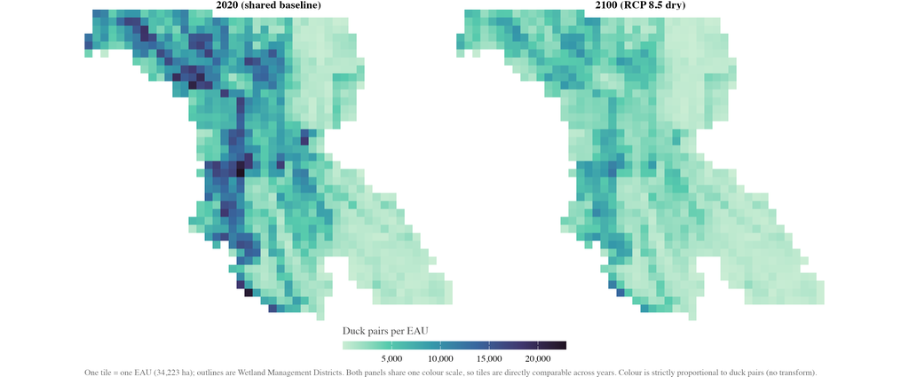

Figure 1: **Duck-pair abundance across the PPR: 2020 baseline vs. 2100 under RCP 8.5 dry.** The 2020 panel is the shared cross-scenario baseline common to all five scenarios — only the 2100 panel is scenario-specific. One tile = one EAU.

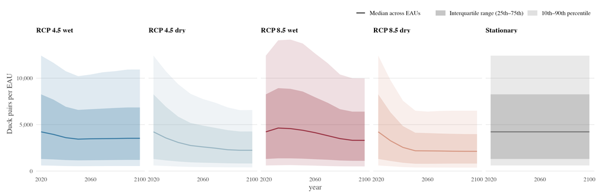

Figure 2: **Per-EAU duck-pair abundance to 2100, by scenario.** Solid line = median across EAUs; dark band = interquartile range; light band = 10th–90th percentile. Bands show spatial variability across EAUs within a given scenario-year.

### Risk

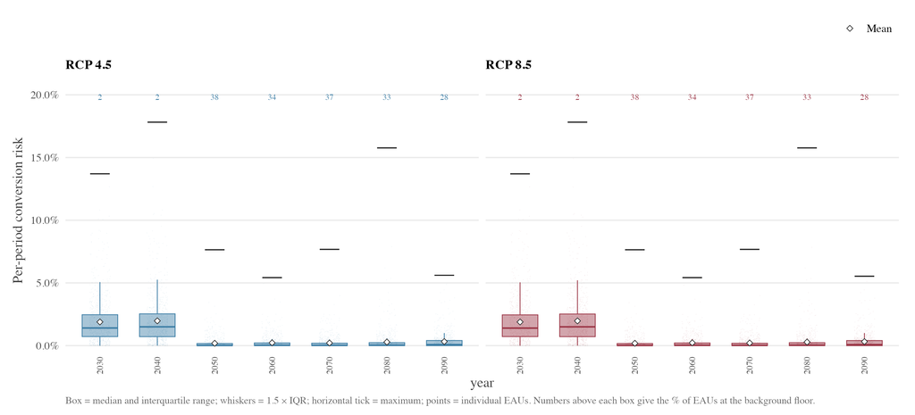

Figure 3: **Per-period conversion risk across EAUs, by decade and emissions scenario.** Box = median and IQR; whiskers = 1.5 × IQR; horizontal tick = maximum; points = individual EAUs. The number above each box is the % of EAUs sitting at the background conversion floor.

### Cost

Acquisition cost per hectare in USD 2020. High cost parcels are concentrated in the eastern portion of the PPR, consistent with other analyses (e.g., Ando and Mallory, 2012).

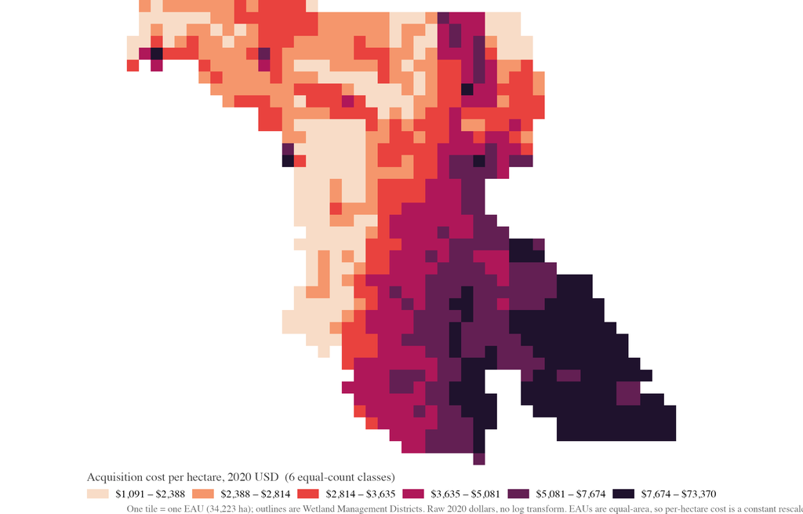

Figure 4: **Acquisition cost per hectare, 2020 USD inflated from 2017.** Raw dollars, no log transform, grouped into six equal-count classes.

## Relative performance of acquisition policies

The major findings of this study compare the difference between total benefit secured across the landscape (2020-2100) under the rolling ILP policy as compared to the greedy or myopic policy. As expected, the rolling policy outperforms both the myopic and the greedy policy; the performance gap between the rolling policy and the greedy policy is larger than the rolling-myopic gap. Rolling provides a 18-20% improvement over myopic, and a ~49-57% improvement over greedy. Under stationarity, there is virtually no difference (as expected, since a stationary environment provides no penalty for policies without foresight). The rolling policy outperforms the myopic and greedy policies under all climate scenarios, consistent with our expectations that an acquisition policy with foresight should outperform a policy with no or limited foresight under any degree of non-stationarity.

Table 1: **Improvement of the rolling policy over greedy and myopic policies, by scenario.**

| Scenario | Acquisition Value (pairs) Greedy | Acquisition Value (pairs) Myopic | Acquisition Value (pairs) Rolling | Rolling vs. Greedy Δpairs | Rolling vs. Greedy % improvement | Rolling vs. Myopic Δpairs | Rolling vs. Myopic % improvement |
| --- | --- | --- | --- | --- | --- | --- | --- |
| RCP 4.5 wet | 120,285 | 156,775 | 189,323 | 69,039 | 57.40% | 32,549 | 20.76% |
| RCP 4.5 dry | 84,318 | 108,656 | 128,523 | 44,205 | 52.43% | 19,866 | 18.28% |
| RCP 8.5 wet | 130,656 | 171,625 | 202,666 | 72,010 | 55.11% | 31,041 | 18.09% |
| RCP 8.5 dry | 74,899 | 94,835 | 112,225 | 37,326 | 49.84% | 17,390 | 18.34% |
| Stationary | 12 | 12 | 13 | <1 | — | <1 | — |

Acquisition Value = cumulative discounted duck-pairs secured relative to the do-nothing baseline, 2020–2100.  
Δpairs = pairs secured through acquisition under rolling − greedy (or myopic).  
% improvement = Δpairs as % of greedy (or myopic).  
— = difference of <1 pair; % improvement not meaningful at this scale.

Another way of describing this is to ask how short of optimal the greedy and myopic policies fall. Here, the rolling policy is used as the provably near-optimal benchmark (MIP gap 0.01% across all rolling solves), and performance gaps are expressed as a % of rolling. The myopic policy falls ~15-17% short of rolling, and the greedy policy falls ~33-36% short of rolling.

Table 2: **Shortfall of greedy and myopic policies relative to the rolling policy, by scenario.**

| Scenario | Acquisition Value (pairs) Greedy | Acquisition Value (pairs) Myopic | Acquisition Value (pairs) Rolling | Greedy vs. Rolling Δpairs | Greedy vs. Rolling % shortfall | Myopic vs. Rolling Δpairs | Myopic vs. Rolling % shortfall |
| --- | --- | --- | --- | --- | --- | --- | --- |
| RCP 4.5 wet | 120,285 | 156,775 | 189,323 | 69,039 | 36.47% | 32,549 | 17.19% |
| RCP 4.5 dry | 84,318 | 108,656 | 128,523 | 44,205 | 34.39% | 19,866 | 15.46% |
| RCP 8.5 wet | 130,656 | 171,625 | 202,666 | 72,010 | 35.53% | 31,041 | 15.32% |
| RCP 8.5 dry | 74,899 | 94,835 | 112,225 | 37,326 | 33.26% | 17,390 | 15.50% |
| Stationary | 12 | 12 | 13 | <1 | — | <1 | — |

Acquisition Value = cumulative discounted duck-pairs secured relative to the do-nothing baseline, 2020–2100.  
Δpairs = secured through acquisition under rolling − greedy (or myopic).  
% shortfall = Δpairs, as % of rolling.  
— = difference of <1 pair; % shortfall not meaningful at this scale.

## Relative performance over time

This graph shows how the gap between the rolling policy and the myopic/greedy policies grows over time. This is presented as net changes in duck pairs, using the rolling policy as a benchmark (value added gap for rolling = 0). As expected, the cumulative gap in performance between rolling and greedy/myopic grows over time (negative values only); and greedy is substantially worse than myopic (red always < yellow).

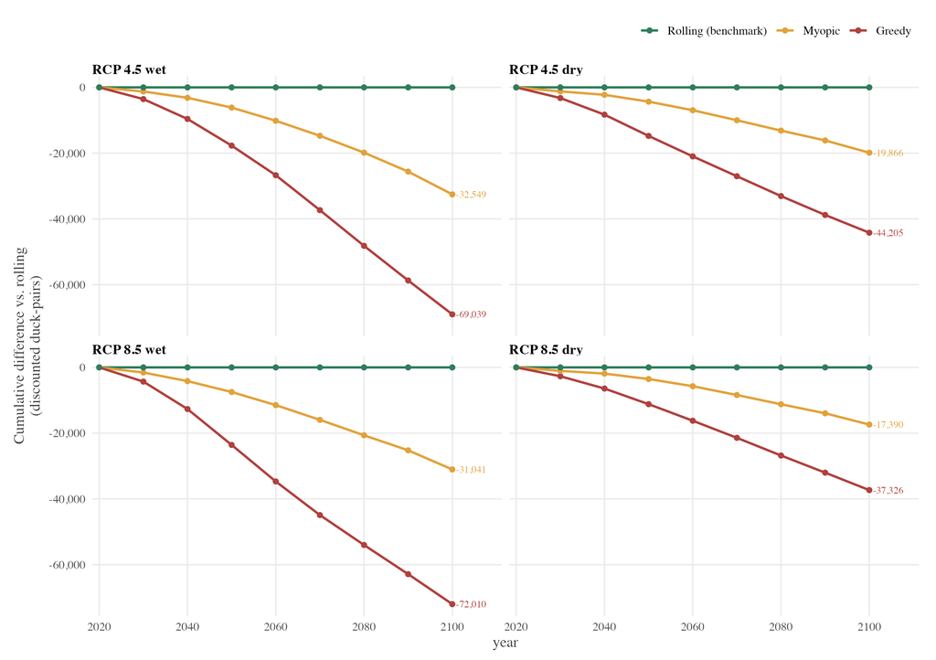

Figure 5: **Cumulative performance relative to the rolling policy.** Discounted duck-pairs secured by the greedy and myopic policies minus those secured by rolling, cumulative to 2100, by climate scenario. Rolling is the near-optimal benchmark (0); MIP gap ~0.01%.

## Acquisition value over baseline

This table compares the total benefit secured across the landscape (2020-2100) through the three acquisition policies against a “do-nothing” baseline scenario in which no parcels are acquired. All acquisition policies outperform the do-nothing baseline under climate change scenarios; there is no improvement under assumptions of stationarity (as expected: stationarity freezes conversion risk to effectively zero).

Even a greedy acquisition policy outperforms a do-nothing policy; myopic and rolling policies each respectively improve upon that baseline. As expected based on the duck density projections, wet/dry scenario is a larger determinant of improvement than RCP scenario.

Overall improvement of any acquisition policy, expressed in % over baseline, is relatively small (0.64% at best). This is likely an artifact of how conversion risk is being calculated in this model (a measure of habitat erosion standing in for habitat conversion probability). It may also be related to a relatively conservative budget parameter (only ~60-70 EAUs are acquired in most scenarios). That said, these numbers might not be that different from real world estimates: Kemnick et al 2023 estimated that the program impact for SWAP was “an avoided loss between 0.00% and 0.02% of the carrying capacity for broods and breeding waterfowl from 2008–2017.”

Table 3: **Value of acquisition policy over do-nothing baseline, by scenario.**

| Scenario | Greedy % over baseline | Greedy Δpairs | Myopic % over baseline | Myopic Δpairs | Rolling % over baseline | Rolling Δpairs |
| --- | --- | --- | --- | --- | --- | --- |
| RCP 4.5 wet | 0.40% | 120,285 | 0.53% | 156,775 | 0.64% | 189,323 |
| RCP 4.5 dry | 0.36% | 84,318 | 0.46% | 108,656 | 0.54% | 128,523 |
| RCP 8.5 wet | 0.40% | 130,656 | 0.52% | 171,625 | 0.62% | 202,666 |
| RCP 8.5 dry | 0.35% | 74,899 | 0.45% | 94,835 | 0.53% | 112,225 |
| Stationary | <0.0001% | 12 | <0.0001% | 12 | <0.0001% | 13 |

## Acquisitions by policy: rolling vs myopic

This map shows parcels that are acquired under both rolling and myopic acquisition schedules; those that are acquired only under rolling; and those that are acquired only under myopic. Light blue parcels are those that are purchased only under an optimal acquisition policy; the myopic model skips these parcels. The orange parcels are ones that the myopic policy purchased but the rolling policy declined to purchase. Interpretation here is that light blue parcels are where the rolling policy’s advantage comes from; orange is where the myopic dedicated funds sub-optimally.

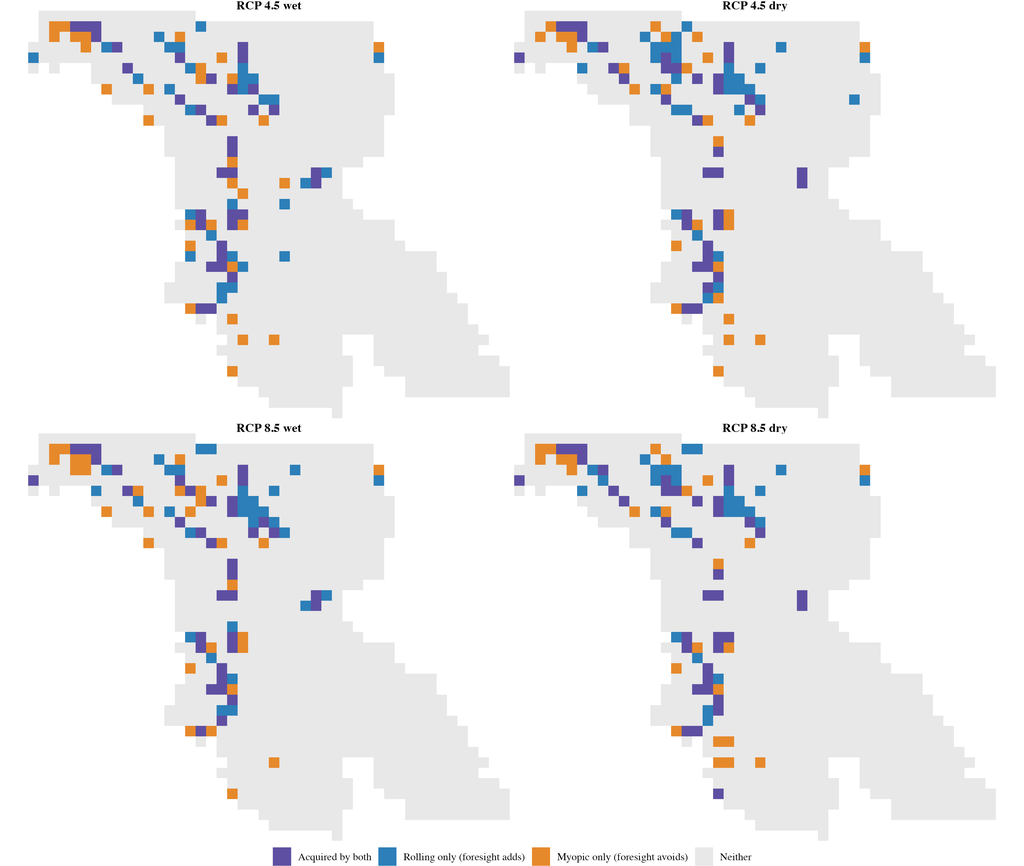

Figure 6: **Rolling vs. myopic acquisition sets.** EAUs colored by which policy buys them, under each climate scenario. Purple cells are parcels acquired under both policies; blue cells are purchased only under the rolling policies; orange cells are purchased by the myopic policy but avoided by the rolling policy.

# Updates

### 10/26/2026: Conversion-hazard sweep

In an effort to compare our model results to published estimates of landscape-scale conversion rates for wetlands and grasslands, I re-ran the model with conversion risk rescaled to different conversion rates. The FORESce derived conversion risk data acts as a lower bound: the landscape average of suitable-to-unsuitable habitat transition is equivalent to a 0.17% annual rate in 2020. Other published estimates vary, ranging from 0.28% (Johnston et al 2013) to 1.33% (Rashford et al. 2011).

I re-scaled all conversion risk values so that the landscape-wide 2020 conversion rate (i.e., the share of all unprotected suitable habitat converted per decade) equaled the target rate. I calculated a scaling factor, k, which would bring the landscape-scale conversion rate to the target (literature-derived) rate, then applied that scaling factor to the conversion risk table in every EAU in every decade. This approach multiplies the underlying conversion rate by the same factor in every EAU, decade and scenario, so the spatial pattern and the trajectory of conversion risk over time (including the mid-century collapse under GCAM) are unchanged. Benefit, cost, budget and land cover are identical to the original run.

Table 4: Improvement of the rolling policy over greedy/myopic, and of myopic over greedy, across conversion rates. Range across the four climate scenarios.

| Annual rate | Run Benchmark | Run k | Myopic vs. Greedy value of using risk | Rolling vs. Myopic value of foresight | Rolling vs. Greedy total | Ranking holds all scenarios |
| --- | --- | --- | --- | --- | --- | --- |
| 0.17% | FOREsce derived | 1.00 | 26.6–31.4% | 18.1–20.8% | 49.8–57.4% | Yes |
| 0.28% | Johnston 2013 | 1.63 | 23.7–30.3% | 17.6–22.1% | 48.4–55.4% | Yes |
| 0.40% | Stephens 2008 | 2.34 | 23.5–31.3% | 15.2–18.9% | 46.7–53.4% | Yes |
| 0.57% | Kemink 2023 | 3.35 | 23.0–29.1% | 15.5–20.0% | 44.6–50.8% | Yes |
| 0.95% | Rashford 2011 (2006–11) | 5.67 | 17.2–24.2% | 16.3–20.8% | 40.3–46.0% | Yes |
| 1.33% | Rashford 2011 | 8.06 | 14.2–20.5% | 14.6–19.6% | 36.6–41.7% | Yes |

% improvement = (better policy − comparison policy) as % of the comparison policy's value; range across the four climate scenarios.  
Annual rate = target rate per year; for the canonical run, its habitat-weighted 2020 rate.

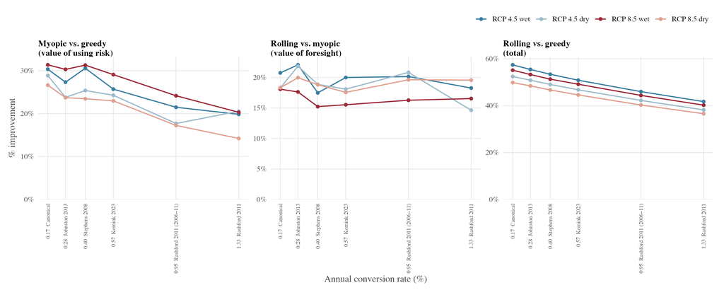

Figure 7: **Policy performance across conversion rates (% improvement).** Left: myopic vs. greedy (value of using conversion risk); middle: rolling vs. myopic (value of foresight); right: rolling vs. greedy (total). Each tick gives the annual rate and the estimate it stands for.

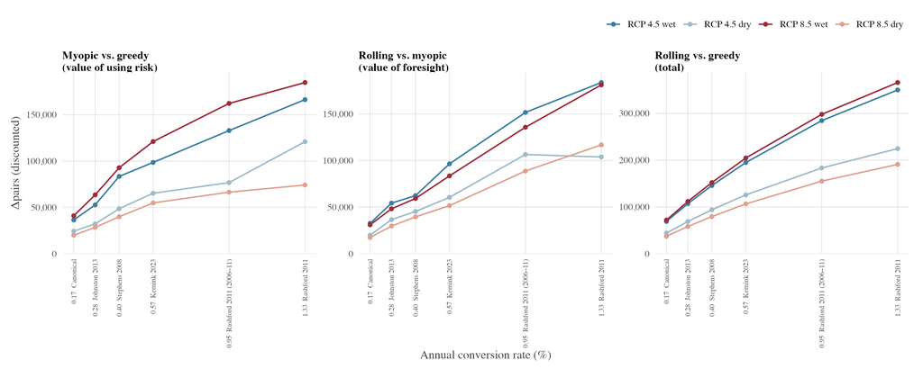

Figure 8: Policy performance across conversion rates ($\Delta$pairs). Same comparisons as the previous figure, in discounted duck-pairs rather than percent.

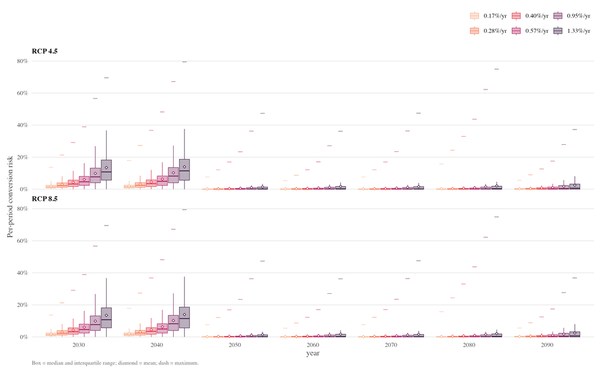

Figure 9: **Per-period conversion risk across EAUs, by decade and emissions scenario.** Colour = annual conversion rate of each run (FOREsce derived = lightest). Box = median and IQR; diamond = mean; dash = maximum.

### 10/21/2026: Budget sensitivity analysis

We wanted to explore the role of budget in determining the relatively performance of the three acquisition policies, as well as the overall performance over the do-nothing baseline. I re-ran the model with a stricter budget constraint (2 median-priced EAUs acquired per period) and a more generous budget constraint (10 median-priced EAUs per period) under all climate scenarios, using the GCAM reference landcover scenario.

I found that across climate scenarios, a stricter budget constraint increased the performance gap between acquisition policies. When only 2 median-priced EAUs can be purchased per decision period, the rolling policy outperforms greedy/myopic policy by ~ 75%/25%; when 10 median-priced EAUs can be purchased per decision period, the rolling policy outperforms the greedy/myopic policy by only ~ 35%/~15%.

**The value of foresight increases under a stricter budget, and declines under a more generous budget**.

Table 5: **Improvement of the rolling policy over greedy and myopic policies, by budget and scenario.**

| Scenario | Budget | Acquisition Value (pairs) Greedy | Acquisition Value (pairs) Myopic | Acquisition Value (pairs) Rolling | Rolling vs. Greedy Δpairs | Rolling vs. Greedy % improvement | Rolling vs. Myopic Δpairs | Rolling vs. Myopic % improvement |
| --- | --- | --- | --- | --- | --- | --- | --- | --- |
| RCP 4.5 wet | 2 | 55,369 | 76,922 | 97,360 | 41,991 | 75.84% | 20,438 | 26.57% |
|  | 5 | 120,285 | 156,775 | 189,323 | 69,039 | 57.40% | 32,549 | 20.76% |
|  | 10 | 224,489 | 263,765 | 306,170 | 81,681 | 36.39% | 42,405 | 16.08% |
| RCP 4.5 dry | 2 | 36,905 | 51,078 | 63,435 | 26,530 | 71.89% | 12,358 | 24.19% |
|  | 5 | 84,318 | 108,656 | 128,523 | 44,205 | 52.43% | 19,866 | 18.28% |
|  | 10 | 152,346 | 178,064 | 208,641 | 56,295 | 36.95% | 30,578 | 17.17% |
| RCP 8.5 wet | 2 | 58,285 | 84,955 | 103,709 | 45,424 | 77.93% | 18,755 | 22.08% |
|  | 5 | 130,656 | 171,625 | 202,666 | 72,010 | 55.11% | 31,041 | 18.09% |
|  | 10 | 237,263 | 284,150 | 328,336 | 91,073 | 38.38% | 44,186 | 15.55% |
| RCP 8.5 dry | 2 | 32,497 | 44,038 | 55,034 | 22,537 | 69.35% | 10,995 | 24.97% |
|  | 5 | 74,899 | 94,835 | 112,225 | 37,326 | 49.84% | 17,390 | 18.34% |
|  | 10 | 136,174 | 155,710 | 183,363 | 47,189 | 34.65% | 27,653 | 17.76% |
| Stationary | 2 | 6 | 6 | 6 | <1 | — | <1 | — |
|  | 5 | 12 | 12 | 13 | <1 | — | <1 | — |
|  | 10 | 21 | 21 | 21 | <1 | — | <1 | — |

Acquisition Value = cumulative discounted duck-pairs secured relative to the do-nothing baseline, 2020–2100.  
Δpairs = pairs secured through acquisition under rolling − greedy (or myopic).  
% improvement = Δpairs as % of greedy (or myopic).  
— = difference of <1 pair; % improvement not meaningful at this scale.

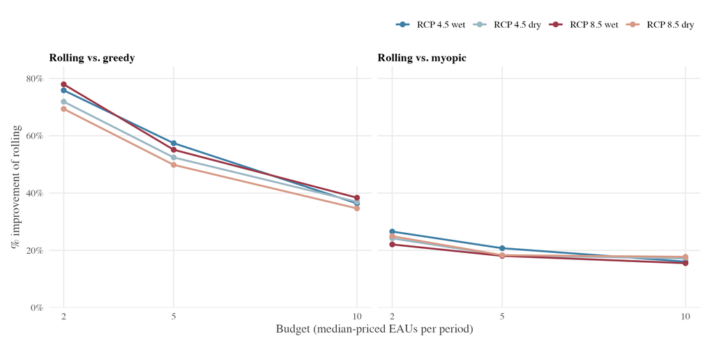

Figure 10: **Improvement of the rolling policy over greedy and myopic policies, by budget.** % improvement = (rolling − comparison policy) as % of the comparison policy’s acquisition value. Budget = median-priced EAUs per period.

Table 6: **Shortfall of greedy and myopic policies relative to the rolling policy, by budget and scenario.**

| Scenario | Budget | Acquisition Value (pairs) Greedy | Acquisition Value (pairs) Myopic | Acquisition Value (pairs) Rolling | Greedy vs. Rolling Δpairs | Greedy vs. Rolling % shortfall | Myopic vs. Rolling Δpairs | Myopic vs. Rolling % shortfall |
| --- | --- | --- | --- | --- | --- | --- | --- | --- |
| RCP 4.5 wet | 2 | 55,369 | 76,922 | 97,360 | 41,991 | 43.13% | 20,438 | 20.99% |
|  | 5 | 120,285 | 156,775 | 189,323 | 69,039 | 36.47% | 32,549 | 17.19% |
|  | 10 | 224,489 | 263,765 | 306,170 | 81,681 | 26.68% | 42,405 | 13.85% |
| RCP 4.5 dry | 2 | 36,905 | 51,078 | 63,435 | 26,530 | 41.82% | 12,358 | 19.48% |
|  | 5 | 84,318 | 108,656 | 128,523 | 44,205 | 34.39% | 19,866 | 15.46% |
|  | 10 | 152,346 | 178,064 | 208,641 | 56,295 | 26.98% | 30,578 | 14.66% |
| RCP 8.5 wet | 2 | 58,285 | 84,955 | 103,709 | 45,424 | 43.80% | 18,755 | 18.08% |
|  | 5 | 130,656 | 171,625 | 202,666 | 72,010 | 35.53% | 31,041 | 15.32% |
|  | 10 | 237,263 | 284,150 | 328,336 | 91,073 | 27.74% | 44,186 | 13.46% |
| RCP 8.5 dry | 2 | 32,497 | 44,038 | 55,034 | 22,537 | 40.95% | 10,995 | 19.98% |
|  | 5 | 74,899 | 94,835 | 112,225 | 37,326 | 33.26% | 17,390 | 15.50% |
|  | 10 | 136,174 | 155,710 | 183,363 | 47,189 | 25.74% | 27,653 | 15.08% |
| Stationary | 2 | 6 | 6 | 6 | <1 | — | <1 | — |
|  | 5 | 12 | 12 | 13 | <1 | — | <1 | — |
|  | 10 | 21 | 21 | 21 | <1 | — | <1 | — |

Acquisition Value = cumulative discounted duck-pairs secured relative to the do-nothing baseline, 2020–2100.  
Δpairs = secured through acquisition under rolling − greedy (or myopic).  
% shortfall = Δpairs, as % of rolling.  
— = difference of <1 pair; % shortfall not meaningful at this scale.

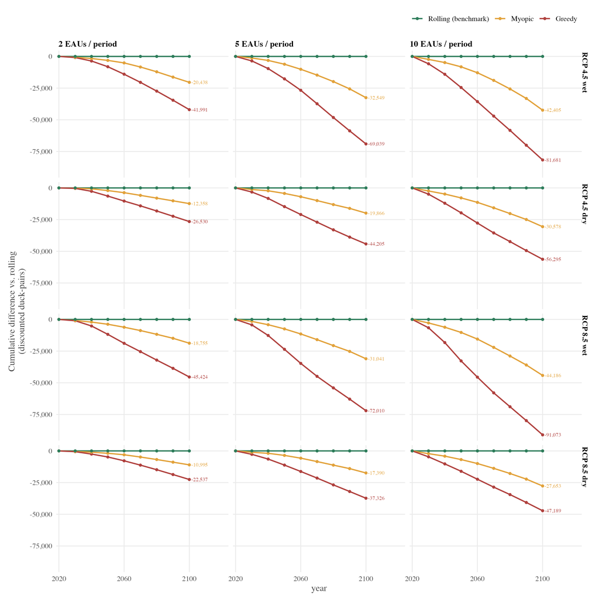

Figure 11: **Cumulative performance relative to the rolling policy, by budget.** Discounted duck-pairs secured by the greedy and myopic policies minus those secured by rolling, cumulative to 2100. Rows = climate scenario; columns = budget (median-priced EAUs per period). Rolling is the benchmark (0).

Table 7: **Value of acquisition policy over do-nothing baseline, by budget and scenario.**

| Scenario | Budget | Greedy % over baseline | Greedy Δpairs | Myopic % over baseline | Myopic Δpairs | Rolling % over baseline | Rolling Δpairs |
| --- | --- | --- | --- | --- | --- | --- | --- |
| RCP 4.5 wet | 2 | 0.19% | 55,369 | 0.26% | 76,922 | 0.33% | 97,360 |
|  | 5 | 0.40% | 120,285 | 0.53% | 156,775 | 0.64% | 189,323 |
|  | 10 | 0.75% | 224,489 | 0.89% | 263,765 | 1.03% | 306,170 |
| RCP 4.5 dry | 2 | 0.16% | 36,905 | 0.22% | 51,078 | 0.27% | 63,435 |
|  | 5 | 0.36% | 84,318 | 0.46% | 108,656 | 0.54% | 128,523 |
|  | 10 | 0.65% | 152,346 | 0.75% | 178,064 | 0.88% | 208,641 |
| RCP 8.5 wet | 2 | 0.18% | 58,285 | 0.26% | 84,955 | 0.32% | 103,709 |
|  | 5 | 0.40% | 130,656 | 0.52% | 171,625 | 0.62% | 202,666 |
|  | 10 | 0.72% | 237,263 | 0.87% | 284,150 | 1.00% | 328,336 |
| RCP 8.5 dry | 2 | 0.15% | 32,497 | 0.21% | 44,038 | 0.26% | 55,034 |
|  | 5 | 0.35% | 74,899 | 0.45% | 94,835 | 0.53% | 112,225 |
|  | 10 | 0.64% | 136,174 | 0.73% | 155,710 | 0.86% | 183,363 |
| Stationary | 2 | <0.0001% | 6 | <0.0001% | 6 | <0.0001% | 6 |
|  | 5 | <0.0001% | 12 | <0.0001% | 12 | <0.0001% | 13 |
|  | 10 | <0.0001% | 21 | <0.0001% | 21 | <0.0001% | 21 |

Δpairs = cumulative discounted duck-pairs secured relative to the do-nothing baseline, 2020–2100.

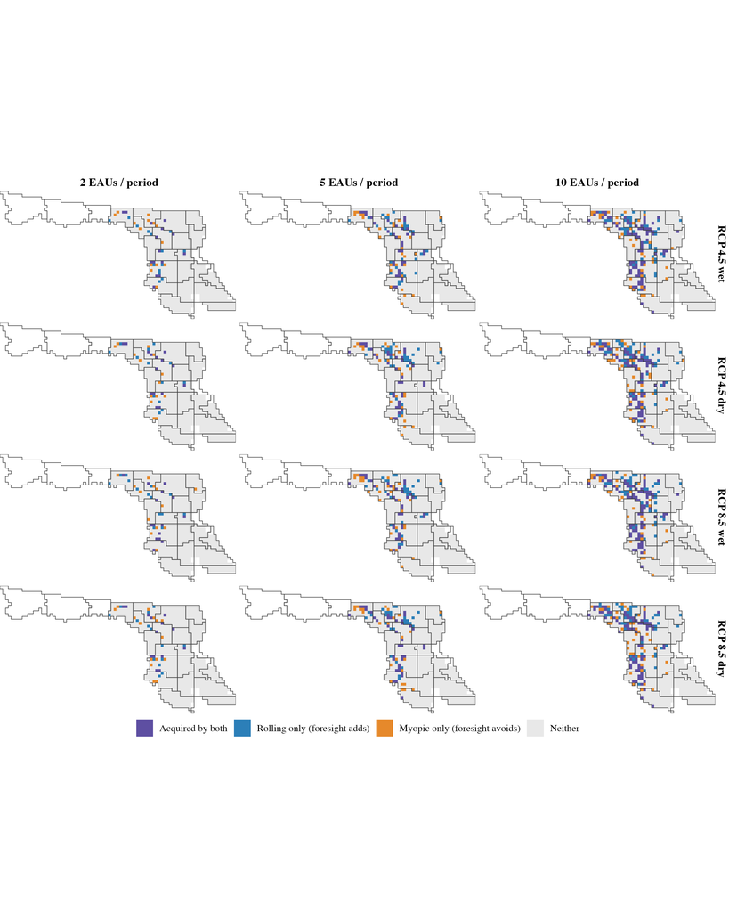

Figure 12: **Rolling vs. myopic acquisition sets, by budget.** EAUs colored by which policy buys them. Rows = climate scenario; columns = budget (median-priced EAUs per period). Purple cells are acquired under both policies; blue cells only under the rolling policy; orange cells are bought by the myopic policy but avoided by the rolling policy.

### 10/21/2026: Land-cover scenario comparison (GCAM reference vs. BAU)

In order to explore the role of landcover trends and patterns on model results, I re-ran the model with another FOREsce projection (BAU). Both BAU and GCAM reference are considered to be likely scenarios in a world with no major agricultural or climate policy changes (as per the FORESce description):

- BAU: “Based on an extrapolation of recent land-cover trends as derived from remote-sensing data. Overall trends were provided by 2001 to 2011 change in the National Land Cover Database, while change in crop types were extrapolated from 2008 to 2014 change in the Cropland Data Layer. Overall the scenario is marked by expansion of high-value traditional crops (corn, soybeans, cotton), with a concurrent decline in dryland wheat and some other lower-value crops.”
- GCAM: “Based on global-scale scenarios from the GCAM model, the”reference” scenario provides a likely landscape under a world without specific carbon or climate mitigation efforts. As such, it’s another form of a “business-as-usual” scenario.”

I wanted to compare these to see how changes in landcover estimations might affect model results, and specifically to see if the BAU scenario contained higher conversion rates than the GCAM scenario; it was noticeable in the GCAM scenario that conversion rates declined markedly mid-century, and wanted to explore what effect that would have.

Table 8: Improvement of the rolling policy over greedy/myopic, GCAM ref vs. BAU land cover.

| Scenario | Rolling vs. Greedy GCAM ref | Rolling vs. Greedy BAU | Rolling vs. Greedy Δ pp | Rolling vs. Myopic GCAM ref | Rolling vs. Myopic BAU | Rolling vs. Myopic Δ pp | Ranking holds both runs |
| --- | --- | --- | --- | --- | --- | --- | --- |
| RCP 4.5 wet | 57.4% | 32.1% | -25.3 | 20.8% | 6.7% | -14.1 | Yes |
| RCP 4.5 dry | 52.4% | 42.1% | -10.4 | 18.3% | 5.7% | -12.5 | Yes |
| RCP 8.5 wet | 55.1% | 35.2% | -19.9 | 18.1% | 6.9% | -11.2 | Yes |
| RCP 8.5 dry | 49.8% | 49.0% | -0.9 | 18.3% | 6.5% | -11.9 | Yes |

% improvement = (rolling − comparison policy) as % of the comparison policy's value.  
Δ pp = BAU − GCAM ref, in percentage points; red = larger than 2 pp.

I believe this is driven by different patterns in conversion risk: under GCAM, conversion to cropland is concentrated in the first two decades and then flattens to nearly zero mid-century and never recovers. This has two effects: the overall value of any acquisition policy through 2100 as compared to a do-nothing baseline is relatively low (since conversion risk in most decades is near zero), and the greedy/myopic policy significantly under perform the rolling policy in early decades (since they assumes continued high conversion risk when in fact conversion risk collapses).

Under BAU, by contrast, the conversion risk is relatively stable across the entire study period. There is decadal variability, but there is no consistent mid-century collapse. This results in a reversal of the two effects: the overall value of any acquisition policy through 2100 as compared to a do-nothing baseline is higher; and greedy/myopic policy assumption of constant conversion risk is in fact pretty close to true.

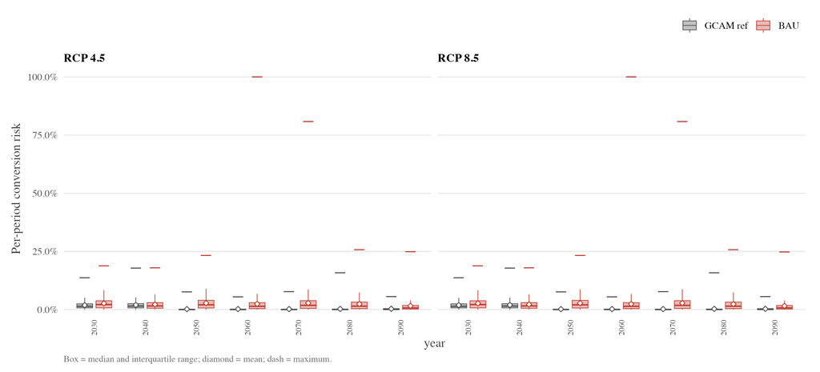

Figure 13: **Per-period conversion risk across EAUs, by decade, emissions scenario and land-cover scenario. Note that conversion risk collapses mid-century in GCAM, but stays constant in BAU.** Grey = GCAM ref; red = BAU. Box = median and IQR; diamond = mean; dash = maximum.

Table 9: Acquisition value (cumulative discounted duck-pairs secured relative to the do-nothing baseline, 2020–2100), by policy and land-cover run. Note the absolute improvement of any acquisition policy, relative to do-nothing, in BAU vs GCAM.

| Scenario | Greedy GCAM ref | Greedy BAU | Greedy Δ% | Myopic GCAM ref | Myopic BAU | Myopic Δ% | Rolling GCAM ref | Rolling BAU | Rolling Δ% |
| --- | --- | --- | --- | --- | --- | --- | --- | --- | --- |
| RCP 4.5 wet | 120,285 | 355,642 | +195.7% | 156,775 | 440,431 | +180.9% | 189,323 | 469,964 | +148.2% |
| RCP 4.5 dry | 84,318 | 207,781 | +146.4% | 108,656 | 279,120 | +156.9% | 128,523 | 295,156 | +129.7% |
| RCP 8.5 wet | 130,656 | 349,239 | +167.3% | 171,625 | 441,595 | +157.3% | 202,666 | 472,109 | +132.9% |
| RCP 8.5 dry | 74,899 | 178,067 | +137.7% | 94,835 | 249,143 | +162.7% | 112,225 | 265,242 | +136.3% |
| Stationary | 12 | 9 | -26.9% | 12 | 9 | -27.0% | 13 | 9 | -27.2% |

Δ% = change in acquisition value, BAU relative to GCAM ref.

I think this comparison is an interesting way to show how the model can help us understand the value of time-dependent acquisition policies in different systems. My primary take away from this is that the trajectory of conversion risk is more important than actual scale of conversion risk for determining the value/utility of a time-dependent acquisition policy as compared to a traditional (greedy/myopic) policy. I don’t know that we need to report BAU results alongside GCAM results, but perhaps include the comparison as a sensitivity analysis in supplementary materials?

### 9/30/2026: Protected Area Removal

In examining the conversion risk, we realized that the previous conversion risk included protected area in the total pool of potentially available habitat, which artificially diluted the estimated conversion risk. To address this, I overlayed the USGS Protected Area Database (PADUS) and calculated the gross suitable habitat loss with protected areas removed. This revised gross suitable habitat rate was used in the risk of loss calculation (i.e., script 05); however, the other uses of landcover data (such as distributing waterfowl density within a WMD) continue to use the unmasked raster with protected areas included.

To overlay the PADUS layer, I used the PAD-US 4.1 Vector Analysis (USGS GAP, 2024, PAD-US 4.1, https://doi.org/10.5066/P96WBCHS) and masked out polygons marked as GAP Status Code 1-3 (which covers areas with permanent protection, like National Parks, and areas where “low intensity” land uses is allowed). I then created a 0/1 raster of protected land within the PPR, and removed those areas when calculating the gross habitat loss.

Updating the conversion risk to exclude protected areas increases the comparative performance of the optimal model over the greedy model by ~3-4 percentage points; it’s noticeable, but not a fundamental change to the takeaway message.

### 9/15/2026: Conversion Risk Update: Net vs Gross Habitat loss:

Delving in to the calculations of how I quantified conversion risk, I realized that I was using net rather than gross habitat loss. This was not conceptually consistent with what I presented, which I intended to be the proportion of suitable habitat in time t that was lost by time t+1 (a flow). Instead, I had calculated the difference between the stock of suitable habitat in time t - t+1, which reflects both losses and gains in suitable habitat.

I changed the calculations to see going from net to gross would affect the estimate of conversion risk. I found that there is a fair amount of habitat recovery in the FOREsce models, so some of those habitat gains showed in the net calculation were concealing real habitat losses. The table below compares the net vs gross habitat loss rate (gross > net in all decades but particularly mid-century). In addition, the use of the net metric in the first model run meant that some EAUs had a “positive” habitat loss (i.e., overall habitat gain), which I corrected for by imposing a data-derived epsilon (floor). With the gross metric, that is no longer needed (net loss >= 0). The table also shows the percent of EAUs that were “censored” by the artificial floor (i.e., which really had habitat loss but which was hidden by habitat gain).

| Decade | gross | net | % of EAUs censored |  |
| --- | --- | --- | --- | --- |
| 2020–2040 | ~0.018 | ~0.017 | 0.5–7% |  |
| **2050–2070 (4.5)** | ~0.002 | 0.0009 | **14–17%** |  |
| **2050–2070 (8.5)** | ~0.002 | −0.0009 | **16–24%** |  |
| 2080–2090 | ~0.003 | ~0.002 | ~4% |  |

While we were missing meaningful habitat loss by using the net metric, changing to the gross metric didn’t substantially change the overall model results. When I used gross instead of net habitat loss, this increased the performance of the rolling model over the greedy model by ~1-2 percentage points.

### 7/30/2026: Spatial Join error

I discovered an error in the spatial join of the extracted land cover data and the model’s data panel. I realized that the landcover data was joined to EAUs by row position, which introduced errors- land classification (% suitable habitat) was joined to the wrong EAUs. Conversion risk (hazard) was the variable most affected- the trans_prob were not attached to the correct spatial unit. Because duck density is distributed according to % suitable, it also meant that duck distributions were incorrect- but the scale of this error was mitigated by the fact that WMD-scale determines the absolute amount of duck density. This meant that WMD level abundance numbers are fine, but distribution within WMD to EAUs was incorrect; cost numbers are unaffected.

Because of this, I had incorrectly believed that most of the EAUs with missing landcover data were concentrated in Winsom, which is why I removed it- but I discovered that this wasn’t actually the case. There were in fact multiple WMDs with at least a few EAUs missing data. I needed to make a cut off threshold (% EAU with missing data above which the WMD would be excluded); I decided to make a cap of 20% (i.e., any WMD missing 20% of EAU land cover data would be excluded). This removed one WMD (Fergus Falls), and left ~8 WMDs with some small % of landcover data missing (2-13%). Note that this means that in those remaining WMDs, the full WMD duck numbers are more densely concentrated in the remaining EAUs.

When I fixed this, I saw that the spatial distribution of duck abundance is now more clearly aligned with McKenna 2026 (good news!). Compare Fig. 1 with Fig. 1 from “results_07302026”. There is also now a clearer alignment of duck abundance and LOW acquisition cost: this is more consistent with the literature, which regularly finds that the highest duck abundance is in the western PPR where land prices are also lower. But the major model findings don’t change at all (i.e., rolling outperforms both myopic and greedy, overall acquisition rate remains low)

## 7/10/2026: Temporal alignment of benefit data

After the initial model run, I realized there was a problem with the temporal alignment of the benefit data with the landcover data (and the decision model itself). The benefit data is as follows:

- “Obs” = mean 2007–2017
- “3059” = mean 2030–2059
- “7099” = mean 2070–2099

Originally, I had aligned it as follows:

- “Obs” = mean 2007–2017 -> 2020
- “3059” = mean 2030–2059 -> 2050
- “7099” = mean 2070–2099 -> 2100

**After talking with Owen, I updated the alignment to use window midpoints**

Notes: The 2020 baseline is produced by interpolating each RCP×GCM combo on its 2012→2045 segment and then averaging across the four combos into one shared period-0 row (preserves the shared-baseline used for the 2020 risk). Decades 2030/2040 interpolate on the 2012→2045 segment; 2050–2080 on the 2045→2085 segment; 2090 and 2100 are held constant at the 2085 value

I re-ran the model with this midpoint temporal alignment of benefit data; saw little difference in model results. My takeaway is that we can reasonably use this midpoint alignment, and importantly that it doesn’t much matter for model results.

Table 10: **Temporal alignment of benefit data: midpoint comparison.**

| Scenario | Greedy Δ % over baseline | Greedy Δpairs | Myopic Δ % over baseline | Myopic Δpairs | Rolling Δ % over baseline | Rolling Δ Δpairs |
| --- | --- | --- | --- | --- | --- | --- |
| RCP 4.5 wet | +0.02% | +2,600 | +0.01% | +305 | +0.02% | +885 |
| RCP 4.5 dry | 0.00% | -3,742 | +0.01% | -5,335 | +0.01% | -8,471 |
| RCP 8.5 wet | -0.01% | -6,610 | 0.00% | -8,285 | -0.01% | -11,626 |
| RCP 8.5 dry | +0.01% | -1,135 | +0.02% | -2,103 | +0.02% | -2,965 |
| Stationary | ≈ 0 | -1 | ≈ 0 | -1 | ≈ 0 | -1 |

Δ = change vs. the primary benefit alignment (midpoint comparison).

Table 11: **Temporal alignment of benefit data: gap vs. rolling (midpoint comparison).**

| Scenario | Greedy Δ gap % | Greedy Δ Δpairs | Myopic Δ gap % | Myopic Δ Δpairs |
| --- | --- | --- | --- | --- |
| RCP 4.5 wet | -1.00% | -1,714 | +0.22% | +581 |
| RCP 4.5 dry | -0.62% | -4,731 | -1.38% | -3,136 |
| RCP 8.5 wet | +0.13% | -5,015 | -0.74% | -3,341 |
| RCP 8.5 dry | -0.44% | -1,829 | -0.34% | -861 |
| Stationary | -0.56% | 0 | +0.21% | 0 |

Δ = change vs. the primary benefit alignment (midpoint comparison).